# Module R’Stat1 : Statistiques simples

francois.rebaudo@ird.fr

Novembre 2019 ; IRD-Montpellier-France CC BY-NC-SA 3.0

# Intervalles de Confiance

## Intervalles de Confiance d’une moyenne, loi normale

- ma variable suit une loi normale
- ou si mon échantillon est de grande taille (n > 30)

=> cas particulier d’un test de conformité du test de Student

## IC, loi normale

```r
xi <- rnorm(mean = 10, sd = 4, n = 100)
t.test(xi, conf.level = 0.95)$conf.int
```

```
## [1]  8.84393 10.45457
## attr(,"conf.level")
## [1] 0.95
```

## Intervalles de confiance d’une moyenne, loi non normale

- ma variable ne suit pas une loi normale
- ou mon échantillon est petit

=> test de conformité de Wilcoxon sur la médiane

## IC, loi non normale

```r
xi <- sample(60:140, size = 15)/10
wilcox.test(xi, conf.int = TRUE, conf.level = 0.95)$conf.int
```

```
## [1]  7.60 10.35
## attr(,"conf.level")
## [1] 0.95
```

## Intervalles de confiance d’un pourcentage

=> test binomial

```r
# 73 individus mâles, sur 153 individus (théoriquement 50%)
binom.test(x = 73, n = 153, p = 0.5)$conf.int
```

```
## [1] 0.3958473 0.5593042
## attr(,"conf.level")
## [1] 0.95
```

## Intervalles de confiance : les autres cas

=> bootstrap

```r
xi <- rpois(n = 100, lambda = 100)
print(xi)
```

```
##   [1]  93  97 104  95 102 122 104  99 115  95  96  99 100 111  95 111 103
##  [18] 106  95  92 106 105  86 130  92 114  92  95  98 100  99  87 107  99
##  [35]  97  98 105  98  94  99  78 114  93 101  96  94 101 102  89  94 109
##  [52]  82  99 100  98  85  84  83 103 112 102 122  84 109  97 108 102 100
##  [69]  91 111  99 101  99 110  92  98 122 120 104 100 110 104 110 105 104
##  [86]  83  90 107  96  98 118 118  97  89  89  90 103  82  87 107
```

## IC, bootstrap

```r
bs <- sapply(1:100, function(i){
  mean(sample(xi, size = 10, replace = TRUE))
})
head(bs)
```

```
## [1] 105.0  96.1  98.9 105.9 102.7  95.3
```

## IC, bootstrap

```r
sort(bs)[c(25, 95)]
```

```
## [1]  98.0 104.8
```

# TD3

# Comparaison d’une moyenne à une référence

## Comp. ref

Les notes des étudiants à un examen par rapport à la moyenne nationale, le taux de glycémie d’un groupe de patient par rapport à la normale, … On cherche à comparer la moyenne d’une série de mesures avec une valeur théorique ou une norme.

## Comp. ref - CAS 1

- Une population suivant une loi Normale de moyenne $\mu = 50$ et d’écart-type $\sigma = 10$.
- Un échantillon de 37 individus, avec une moyenne de $\overline{x}_{obs}=54$.

H0 : La moyenne est égale à la valeur théorique

H1 : La moyenne n’est pas égale à la valeur théorique (soit plus petite, soit plus grande ; bilatéral)

## Comp. ref - CAS 1

La “vraie” moyenne se distribue autour de 50 celon une loi Normale d’écart type 10. L’écart entre la moyenne de l’échantillon et 50 doit être à l’intérieur d’un intervalle à définir en fonction d’un risque $\alpha$.

Les bornes sont les quantiles d’ordre $\alpha/2$ et $1-\alpha/2$ de la statistiwue $\overline{X}_n$.

On fixe $\alpha = 5%$.

## Comp. ref - CAS 1

$\overline{X}_n \sim \mathcal{N}(50 ; 10/\sqrt{37})$

forme centrée réduite :

$Z_n = \frac{\overline{X}_n - 50}{10/\sqrt{37}} \sim \mathcal{N}(0,1)$

## Comp. ref - CAS 1

$bornes = 50 \pm z_{1-\alpha/2} * 10/\sqrt{37}$

```r
qnorm(0.975)
```

```
## [1] 1.959964
```

```r
bSup <- 50 + qnorm(0.975) * 10 / sqrt(37)
bInf <- 50 - qnorm(0.975) * 10 / sqrt(37)
print(paste0("[", round(bInf, digits = 2), " ; ",
  round(bSup, digits = 2), "]"))
```

```
## [1] "[46.78 ; 53.22]"
```

```r
findInterval(x = 54, vec = c(-Inf, bInf, bSup, Inf)) == 2
```

```
## [1] FALSE
```

## Comp. ref - CAS 1

Dans la plupart des cas, l’écart type de la population est inconnu.

- L’écart type doit être estimé à partir de l’échantillon
- Pour les bornes, on substitue la loi Normale par la loi de Student

## Comp. ref - CAS 2

```r
ech <- rnorm(37, mean = 54, sd = 10)
sd(ech) # écart type estimé
```

```
## [1] 11.33244
```

$\mathcal{T}_n = \frac{\overline{X}_n - 50}{S^*_n/\sqrt{37}}$

$\mathcal{T}_n$ suit un loi de Student avec un paramètre $\nu$ (“nu”) égal à $n-1$ (36), nombre de degrés de liberté.

## Comp. ref - CAS 2

$bornes = \mu_0 \pm t_{1-\alpha/2} * s^*/\sqrt{n}$

```r
bInf <- 50 - qt(0.975, df = length(ech) - 1) * sd(ech)/sqrt(length(ech))
bSup <- 50 + qt(0.975, df = length(ech) - 1) * sd(ech)/sqrt(length(ech))
print(paste0("[", round(bInf, digits = 2), " ; ",
  round(bSup, digits = 2), "]"))
```

```
## [1] "[46.22 ; 53.78]"
```

```r
print(mean(ech))
```

```
## [1] 51.97401
```

```r
findInterval(x = mean(ech), vec = c(-Inf, bInf, bSup, Inf)) == 2
```

```
## [1] TRUE
```

## Comp. ref - CAS 2

```r
t.test(ech, mu = 50, alternative = "two.sided")
```

```
##
##  One Sample t-test
##
## data:  ech
## t = 1.0596, df = 36, p-value = 0.2964
## alternative hypothesis: true mean is not equal to 50
## 95 percent confidence interval:
##  48.19559 55.75244
## sample estimates:
## mean of x
##  51.97401
```

## Comp. ref - CAS 2

```r
t <- (mean(ech) - 50) / (sd(ech) / sqrt(length(ech)))
df <- length(ech) - 1
pvalue <- 2 * pt(-abs(t), df = df)
paste("t:", t)
```

```
## [1] "t: 1.05956500721"
```

```r
paste("df:", df)
```

```
## [1] "df: 36"
```

```r
paste("p-value:", pvalue)
```

```
## [1] "p-value: 0.296400137749216"
```

## Comp. ref - CAS 2

```r
t.test(ech, mu = 50, alternative = "less")
```

```
##
##  One Sample t-test
##
## data:  ech
## t = 1.0596, df = 36, p-value = 0.8518
## alternative hypothesis: true mean is less than 50
## 95 percent confidence interval:
##      -Inf 55.11938
## sample estimates:
## mean of x
##  51.97401
```

## Comp. ref - CAS 2

```r
t.test(ech, mu = 50, alternative = "greater")
```

```
##
##  One Sample t-test
##
## data:  ech
## t = 1.0596, df = 36, p-value = 0.1482
## alternative hypothesis: true mean is greater than 50
## 95 percent confidence interval:
##  48.82864      Inf
## sample estimates:
## mean of x
##  51.97401
```

# TD4

# Comparaison d’une moyenne à une référence (suite)

## Comp. ref - CAS 3

Si n est petit (<30) et que la distribution des données n’est pas normale, il faut utiliser un test non paramétrique en substitut au test de Student : c’est le test de Wilcoxon.

```r
wilcox.test(ech, mu = 50, alternative = "two.sided")
```

```
##
##  Wilcoxon signed rank test
##
## data:  ech
## V = 420, p-value = 0.3088
## alternative hypothesis: true location is not equal to 50
```

# Comparaison de groupes

## Comp. gp - CAS 1

Les moyennes sont indépendantes. Par exemple la taille d’individus dans un pays à comparer avec un autre pays. Un contre exemple, la taille de plantes à 10 jours et à 20 jours : la taille à 20 jours va dépendre de la taille déjà atteinte à 10 jours. Un autre cas classique de non-indépendance est la mesure d’individus avant et après un traitement. **Dans ce qui va suivre les mesures doivent être indépendantes, normallement distribuées, et de variance égales (homoscédasticité)**.

## Comp. gp - CAS 1

Avec des individus A et B et $S^2$ un indicateur de la variance globale :

$t = \frac{m_A - m_B}{\sqrt{\frac{S^2}{n_A}+\frac{S^2}{nB}}}$

$S^2 = \frac{\sum{(x-m_A)^2}+\sum{(x-m_B)^2}}{n_A+n_B-2}$

$df = n_A + n_B - 2$

## Comp. gp - CAS 1

```r
gpA <- rnorm(100)
gpB <- rnorm(100)
s2 <- (sum((gpA - mean(gpA))^2) + sum((gpB - mean(gpB))^2)) /
  (length(gpA) + length(gpB) - 2)
t <- (mean(gpA) - mean(gpB))/sqrt(s2/length(gpA) + s2/length(gpB))
df <- length(gpA) + length(gpB) - 2
print(t)
```

```
## [1] 0.220146
```

```r
print(df)
```

```
## [1] 198
```

## Comp. gp - CAS 1

```r
t.test(gpA, gpB, var.equal = TRUE)
```

```
##
##  Two Sample t-test
##
## data:  gpA and gpB
## t = 0.22015, df = 198, p-value = 0.826
## alternative hypothesis: true difference in means is not equal to 0
## 95 percent confidence interval:
##  -0.2720596  0.3404354
## sample estimates:
##  mean of x  mean of y
## 0.12843605 0.09424814
```

## Comp. gp - CAS 2

Si la variance n’est pas la même (cas par défault pour le `t.test()` avec R), alors il faut utiliser le test de Welch (avec $S_A$ et $S_B$ les écart types de A et B) :

$t = \frac{m_A - m_B}{\sqrt{\frac{S_A^2}{n_A}+\frac{S_B^2}{nB}}}$

$df = (\frac{S_A^2}{n_A}+\frac{S_B^2}{n_B^2})^2 / (\frac{S_A^4}{n_A^2(n_A-1)}+\frac{S_B^4}{n_B^2(n_B-1)})$

## Comp. gp - CAS 2

```r
gpA <- rnorm(100)
gpB <- rnorm(100)
sA <- sd(gpA)
sB <- sd(gpB)
t <- (mean(gpA) - mean(gpB))/sqrt(sA^2/length(gpA) + sB^2/length(gpB))
df <- ((sA^2/length(gpA) + sB^2/length(gpB))^2) /
  (sA^4/(length(gpA)^2*(length(gpB)-1))
    + sB^4/(length(gpA)^2*(length(gpB)-1)))
print(t)
```

```
## [1] -0.9625028
```

```r
print(df)
```

```
## [1] 196.6548
```

## Comp. gp - CAS 2

```r
t.test(gpA, gpB)
```

```
##
##  Welch Two Sample t-test
##
## data:  gpA and gpB
## t = -0.9625, df = 196.65, p-value = 0.337
## alternative hypothesis: true difference in means is not equal to 0
## 95 percent confidence interval:
##  -0.4256983  0.1464539
## sample estimates:
##    mean of x    mean of y
## -0.134929343  0.004692867
```

## Comp. gp - CAS 2

En pratique on peut utiliser le test de Student de Welch dans tous les cas car il est plus robuste. [Plus d’information sur le site de Wikipedia](https://en.wikipedia.org/wiki/Welch%27s_t-test).

## Comp. gp - CAS 2

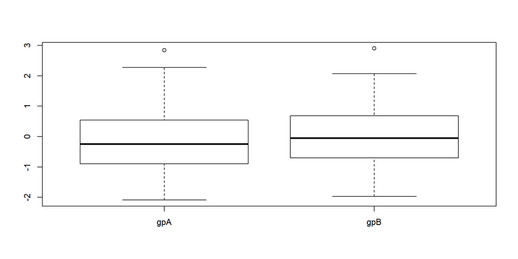

```r
boxplot(gpA, gpB, names = c("gpA", "gpB"))
```

## Comp. gp - CAS 3

Quand les données des groupes ne sont pas distribuées selon une loi Normale.

=> Test de Wilcoxon

## Comp. gp - CAS 3

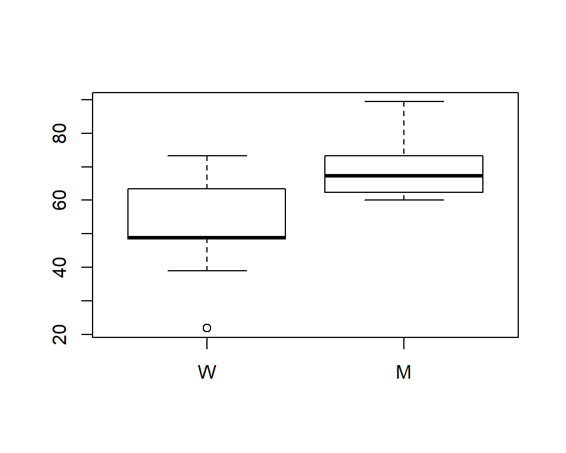

```r
# Données adaptées de http://www.sthda.com
women_weight <- c(38.9, 61.2, 73.2, 21.8,
  63.4, 64.6, 48.4, 48.8, 48.5)
men_weight <- c(67.8, 60, 63.5, 76, 89.4,
  73.3, 67.3, 61.3, 62.4)
boxplot(women_weight, men_weight, names = c("W", "M"))
```

## Comp. gp - CAS 3

```r
wilcox.test(women_weight, men_weight,
  alternative = "two.sided")
```

```
##
##  Wilcoxon rank sum test
##
## data:  women_weight and men_weight
## W = 14, p-value = 0.01876
## alternative hypothesis: true location shift is not equal to 0
```

## Comp. gp - CAS 4

Qaund les données ne sont pas indépendantes !

On calcule la différence entre chaque données appariées (`d`), on vérifie que la distribution de `d` suit une loi Normale. Si la différence moyenne (`m`) est proche de 0, alors il n’y a pas de différence entre les données.

$t = \frac{m}{s/\sqrt{n}}$

$df=n-1$

## Comp. gp - CAS 4

```r
gpA <- rnorm(30)
gpB <- gpA + rnorm(30)
dfGp <- data.frame(gpA = gpA, gpB = gpB)

par(mfrow = c(1, 2))
boxplot(gpA, gpB)
trash <- lapply(seq_along(gpA), function(i){
  points(x = 1:2, y = dfGp[i,], type = 'b', pch = 16)
})

hist(gpA - gpB, main = "")
```

## Comp. gp - CAS 4

[figure not shown]

## Comp. gp - CAS 4

```r
t.test(gpA, gpB, paired = TRUE,
  alternative = "two.sided")
```

```
##
##  Paired t-test
##
## data:  gpA and gpB
## t = -0.17171, df = 29, p-value = 0.8649
## alternative hypothesis: true difference in means is not equal to 0
## 95 percent confidence interval:
##  -0.4400911  0.3719183
## sample estimates:
## mean of the differences
##             -0.03408641
```

## Comp. gp - CAS 5

=> Wilcoxon

## Comp. gp - CAS 5

```r
wilcox.test(gpA, gpB,
  alternative = "two.sided")
```

```
##
##  Wilcoxon rank sum test
##
## data:  gpA and gpB
## W = 444, p-value = 0.9357
## alternative hypothesis: true location shift is not equal to 0
```

# TD5

# Analyse de variance et le modèle linéaire